# L9 - Statistical Sampling

## Lecture Goals

- Understand fundamental concepts of statistical inference
  - Population vs Sample
  - Parameter vs Statistic
  - Sampling Variability & Bias
- Apply basic sampling strategies
  - Simple and Stratified Random Sampling
- Readings
  - [ISRS](https://www.openintro.org/download.php?file=isrs1_tablet&referrer=/stat/textbook.php): ch. 1.3-1.4

## Why Statistics?

- Goal: answer questions about a **population**
  - Population: collection of *all objects of interest* (actual or notional)
  - E.g. What is average age of people living in Canada?
- *Precise* answer for entire population requires **census**
  - E.g. Ask *everyone* living in Canada (cost ~$700mil!)
  - Typically either impracticable or impossible
- Alternatively *sample* the population

## Sampling

- **Sample** is subset of population that helps answer question *"approximately"*

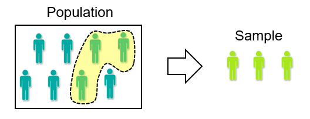

- Answer quality depends critically on how sample is collected

## Parameters & Statistics

- Answers typically expressed as statements about summary measure of interest
  - **Parameter**: summary of entire population
  - **(Sample) Statistic**: summary of sample

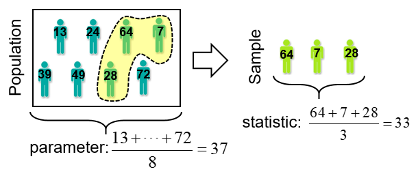

## Notation

- Continuous Variables

| Description | Parameter | Statistic |
| --- | --- | --- |
| Mean/Avg | \(\mu\) | \(\hat{\mu}/\bar{X}\) |
| Std Deviation | \(\sigma\) | \(S\) |
| Median | \(\mu_{1/2}\) | \(M\) |

- Discrete Variables

| Description | Parameter | Statistic |
| --- | --- | --- |
| Proportion | \(p\) | \(\hat{p}\) |

## Example

- Dinesafe data: interested in average number of inspections per establishment

```r
pop = dinesafe %>%
  group_by(ESTABLISHMENT_ID) %>%
  distinct(INSPECTION_ID) %>%
  summarise( N_INSPECTIONS = n() )
pop %>% summarise( mean(N_INSPECTIONS) )
## # A tibble: 1 x 1
##   `mean(N_INSPECTIONS)`
##                   <dbl>
## 1                  3.41
pop %>% sample_n(100) %>% summarise( mean(N_INSPECTIONS) )
## # A tibble: 1 x 1
##   `mean(N_INSPECTIONS)`
##                   <dbl>
## 1                  3.38
```

## Variability

- Statistic value varies with different samples
  - **Sampling variability** is extent to which statistics diverge from their mean
- Sampling variability can be controlled by the **sample size** (\(n\))
  - Larger \(n\) \(\rightarrow\) lower variability (higher accuracy)

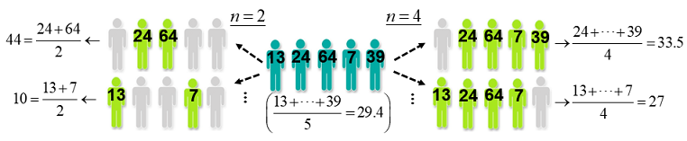

## Example

- Distribution of statistics (avg # of inspections) of different sample sizes

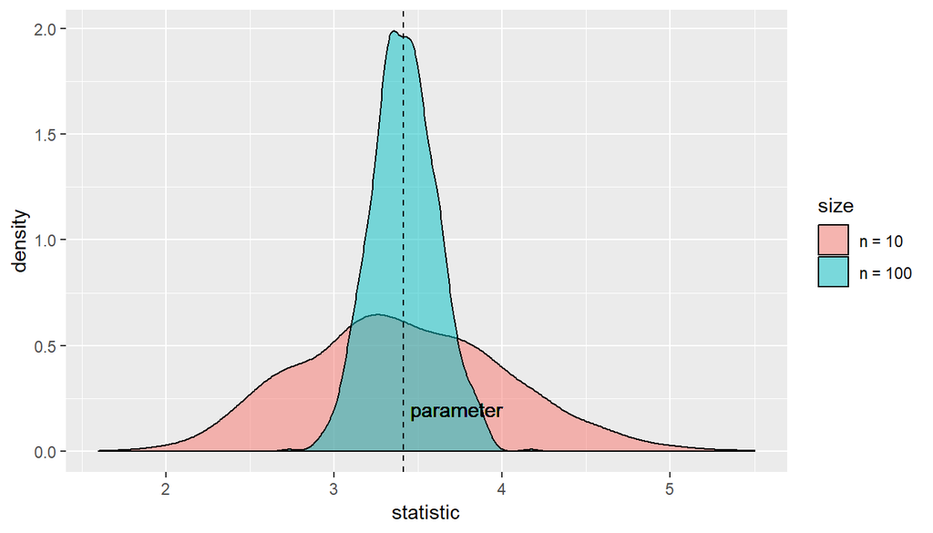

## Bias

- Statistic changes with different samples, so how do we pick our sample?
- Regularities in sampling can lead to **bias**, i.e. systematic deviation of statistic from parameter
  - E.g. collect data by email only
- To avoid selection bias & improve representativeness, most sampling methods involve **randomness**

## Simple Random Sampling

- **Sampling frame**, i.e. list of available objects for sampling
  - Ideally covers entire population
- **Simple Random Sample (SRS)**: every object sampled *randomly and with equal probability*
  - Avoids bias when no other information is available
  - Average of *all* SRS averages equal to population average

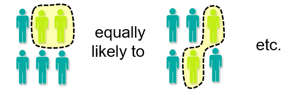

## Example

- Distribution of statistics from different sampling frames (SRS, \(n=100\))

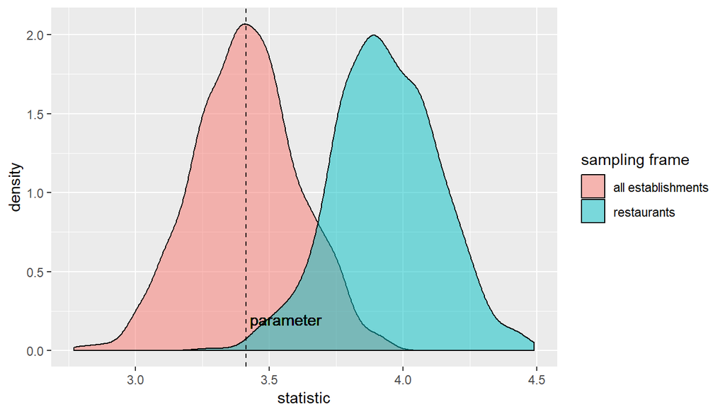

## Potential Problems

- Randomness alone is not enough for representativeness
  - Must pay attention to sampling details

Two common sources of bias are:

- **Participation or Non-response bias**: *respondents* are not representative of entire population
- **Coverage bias**: sampling frame does not align well with population

## Stratified Sampling

- Population often divided into groups, called *strata*
- **Stratified Sampling** combines SRS from every straturm to ensure representation
  - Samples proportional to strata sizes

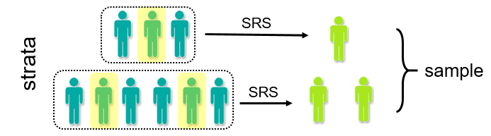

## Example

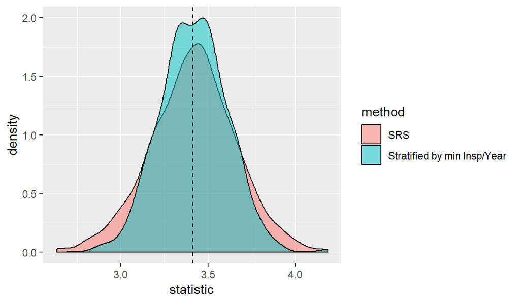

```
## # A tibble: 3 x 3
##   MINIMUM_INSPECTIONS_PERYEAR `mean(N_INSPECTIONS)` `n()`
##                         <int>                 <dbl> <int>
## 1                           1                  1.66  3887
## 2                           2                  3.45  8775
## 3                           3                  5.21  3629
```

## Observational vs Experimental Studies

- **Observational studies** collect data by *observing* what happens (no intervention)
  - E.g. survey sampling, polls, etc.
- **Experiments** collect data after *manipulating* aspects of the process
  - E.g. drug testing
- Observational studies are used for *descriptions* (what *is* happening), whereas experiments are used for *decisions* (what *should* be done)